# DÚ_5

Anna Hlubinová, Jaroslav Maček

2022-12-25

## Dáta

Najprv načítame potrebné knižnice.

```r
library(fGarch)
library(astsa)
library(quantmod)
```

```r
library(urca)
library(ggplot2)
library(ggfortify)
library(forecast)
```

V tejto domácej úlohe budeme pracovať s dátami o výmennom kurze CHF/EUR, ktoré sú za obdobie približne 3 rokov. Keďže stiahnuté dáta už sú v želanom formáte (logaritmické výnosy), po načítaní ich nemusíme upravovať a rovno si ich zobrazíme na grafe.

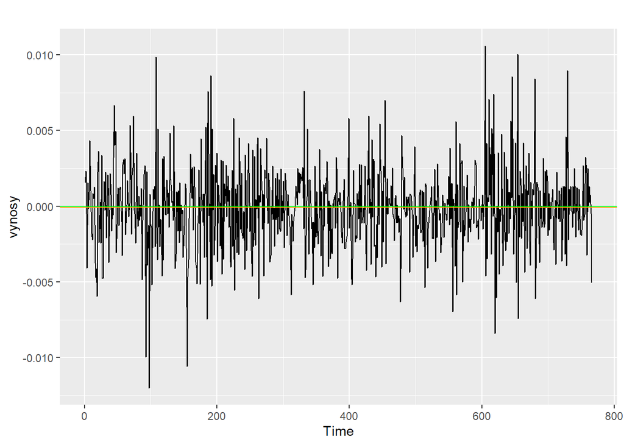

```r
data_ex <- read.table("https://alex-babis.github.io/Casove_Rady_2022/EX_data.txt",header = TRUE, sep = ",")
vynosy <- as.ts(data_ex[,10])
autoplot(vynosy)+
  geom_hline(yintercept = 0, color = "green")+
  geom_hline(yintercept = mean(vynosy), color = "orange")
```

Vidíme, že čiara znázorňujúca priemer dát (oranžová) je takmer totožná s nulovou hladinou (zelená), preto pri testovaní jednotkového koreňa použijeme type=“none”.

```r
jednotkac <- ur.df(vynosy,type = "none", lags = 5, selectlags = "BIC")
summary(jednotkac)
```

```
##
## ###############################################
## # Augmented Dickey-Fuller Test Unit Root Test #
## ###############################################
##
## Test regression none
##
##
## Call:
## lm(formula = z.diff ~ z.lag.1 - 1 + z.diff.lag)
##
## Residuals:
##        Min         1Q     Median         3Q        Max
## -0.0121230 -0.0016155 -0.0000468  0.0013227  0.0106402
##
## Coefficients:
##            Estimate Std. Error t value Pr(>|t|)
## z.lag.1    -1.08903    0.05306 -20.525   <2e-16 ***
## z.diff.lag  0.02499    0.03639   0.687    0.492
## ---
## Signif. codes:  0 '***' 0.001 '**' 0.01 '*' 0.05 '.' 0.1 ' ' 1
##
## Residual standard error: 0.00272 on 758 degrees of freedom
## Multiple R-squared:  0.5304, Adjusted R-squared:  0.5291
## F-statistic:   428 on 2 and 758 DF,  p-value: < 2.2e-16
##
##
## Value of test-statistic is: -20.5246
##
## Critical values for test statistics:
##       1pct  5pct 10pct
## tau1 -2.58 -1.95 -1.62
```

Keďže testová štatistika vyšla rovná -20.5246, teda výrazne menej ako 5% kritická hodnota testu, ktorá je v tomto prípade rovná -1.95, znamená to, že test hypotézu o jednotkovom koreni zamieta. V dátach teda nepozorujeme jednotkový koreň, a preto dáta netreba ďalej diferencovať.

## ARMA model

Teraz sa pozrieme na to, ako vyzerá ACF a PACF pre naše dáta.

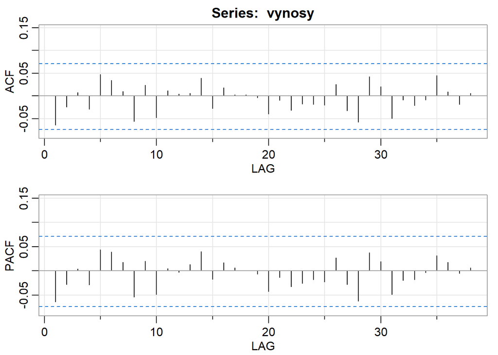

```
##       [,1]  [,2] [,3]  [,4] [,5] [,6] [,7]  [,8] [,9] [,10] [,11] [,12] [,13]
## ACF  -0.06 -0.02 0.01 -0.03 0.05 0.03 0.01 -0.06 0.02 -0.05  0.01     0  0.01
## PACF -0.06 -0.03 0.00 -0.03 0.04 0.04 0.02 -0.05 0.02 -0.05  0.01     0  0.01
##      [,14] [,15] [,16] [,17] [,18] [,19] [,20] [,21] [,22] [,23] [,24] [,25]
## ACF   0.04 -0.03  0.02  0.00     0  0.00 -0.04 -0.01 -0.03 -0.02 -0.02 -0.02
## PACF  0.04 -0.02  0.02  0.01     0 -0.01 -0.04 -0.01 -0.03 -0.03 -0.02 -0.02
##      [,26] [,27] [,28] [,29] [,30] [,31] [,32] [,33] [,34] [,35] [,36] [,37]
## ACF   0.03 -0.03 -0.06  0.04  0.02 -0.05 -0.01 -0.02 -0.01  0.04  0.01 -0.02
## PACF  0.03 -0.03 -0.06  0.04  0.02 -0.05 -0.02 -0.02  0.00  0.03  0.02 -0.01
##      [,38]
## ACF   0.01
## PACF  0.01
```

```r
acf2(vynosy)
```

Nakoľko všetky autokorelácie sú vnútri intervalu spoľahlivosti, usudzujeme, že časový rad by sme mohli považovať za biely šum posunutý o konštantu. Overíme to tak, že zostrojíme ARMA(0,0) model a pozrieme sa na výsledok Ljung-Boxovho testu.

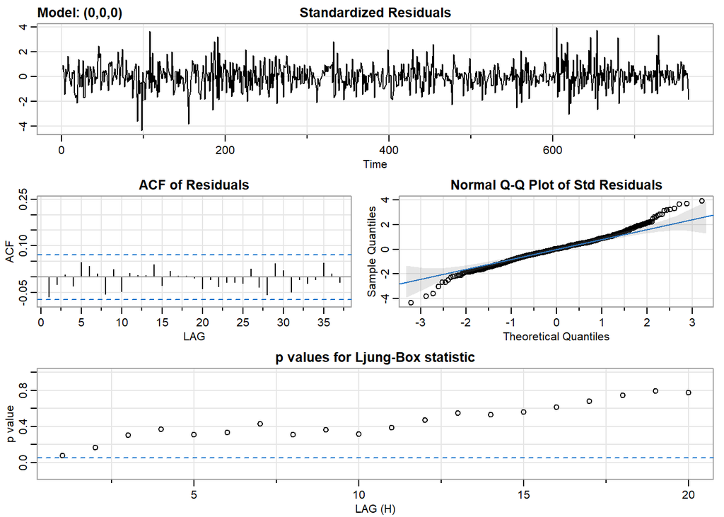

```r
model <- sarima(vynosy,p=0,d=0,q=0)
```

```r
summary(model)
```

```
##                    Length Class  Mode
## fit                14     Arima  list
## degrees_of_freedom  1     -none- numeric
## ttable              4     -none- numeric
## AIC                 1     -none- numeric
## AICc                1     -none- numeric
## BIC                 1     -none- numeric
```

Z výsledkov usudzujeme, že tento model by naozaj mohol vyhovovať. Teda vyzerá to tak, že proces by sme skutočne mohli modelovať pomocou bieleho šumu posunutého o konštantu. Pozrime sa však na to, ako sú na tom rezíduá a ich druhé mocniny.

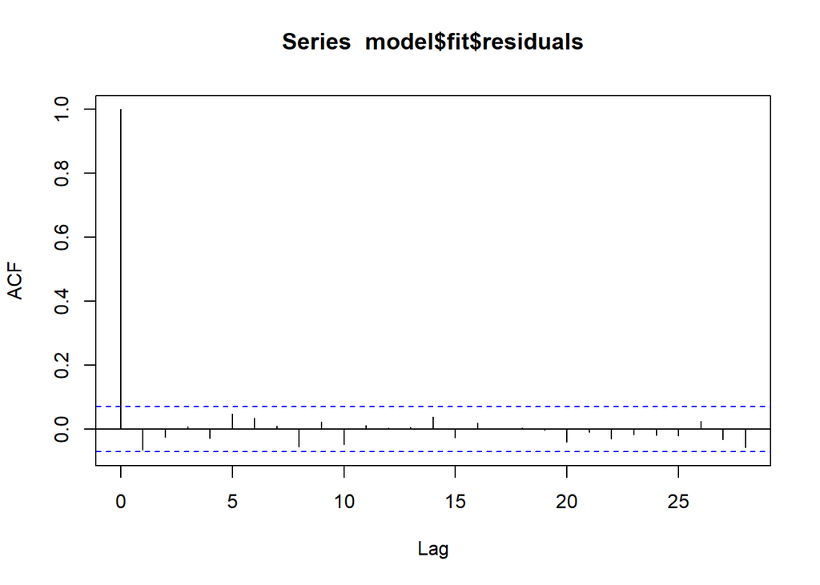

```r
acf(model$fit$residuals)
```

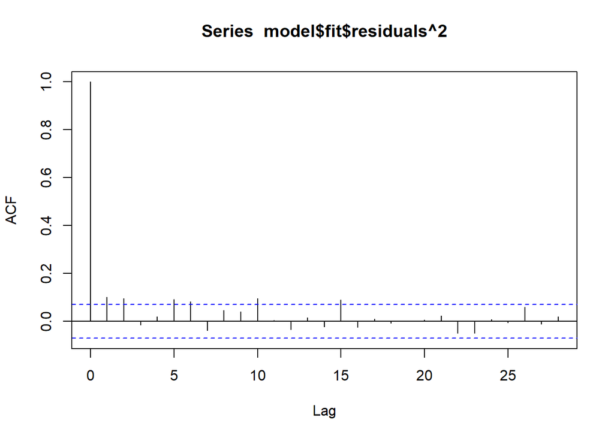

```r
acf(model$fit$residuals^2)
```

Vidíme, že druhé mocniny rezíduí sú zrejme korelované, nakoľko pri viacerých lagoch vychádzajú nad interval spoľahlivosti. Teda o biely šum nepôjde. Prejdeme preto k ARMA+GARCH modelom.

## ARMA+GARCH modely

Ideme hľadať vhodný GARCH model. Ako prvý vyskúšame čisto GARCH(1,1).

```r
gmodel <- garchFit(~garch(1, 1), data = vynosy, trace = FALSE)
summary(gmodel)
```

```
##
## Title:
##  GARCH Modelling
##
## Call:
##  garchFit(formula = ~garch(1, 1), data = vynosy, trace = FALSE)
##
## Mean and Variance Equation:
##  data ~ garch(1, 1)
## <environment: 0x0000018ab0bfbf80>
##  [data = vynosy]
##
## Conditional Distribution:
##  norm
##
## Coefficient(s):
##          mu        omega       alpha1        beta1
## -1.0105e-04   1.4020e-06   1.0028e-01   7.1153e-01
##
## Std. Errors:
##  based on Hessian
##
## Error Analysis:
##          Estimate  Std. Error  t value Pr(>|t|)
## mu     -1.010e-04   9.394e-05   -1.076   0.2821
## omega   1.402e-06   6.675e-07    2.100   0.0357 *
## alpha1  1.003e-01   3.989e-02    2.514   0.0119 *
## beta1   7.115e-01   1.177e-01    6.047 1.48e-09 ***
## ---
## Signif. codes:  0 '***' 0.001 '**' 0.01 '*' 0.05 '.' 0.1 ' ' 1
##
## Log Likelihood:
##  3451.089    normalized:  4.505338
##
## Description:
##  Wed Sep 11 10:54:13 2024 by user: Anna Hlubinová
##
##
## Standardised Residuals Tests:
##                                 Statistic p-Value
##  Jarque-Bera Test   R    Chi^2  103.112   0
##  Shapiro-Wilk Test  R    W      0.9825025 6.229045e-08
##  Ljung-Box Test     R    Q(10)  10.60529  0.3890843
##  Ljung-Box Test     R    Q(15)  12.41349  0.6475001
##  Ljung-Box Test     R    Q(20)  14.46913  0.8059363
##  Ljung-Box Test     R^2  Q(10)  15.58645  0.1120985
##  Ljung-Box Test     R^2  Q(15)  23.8606   0.06749887
##  Ljung-Box Test     R^2  Q(20)  25.5493   0.1812184
##  LM Arch Test       R    TR^2   17.6835   0.125644
##
## Information Criterion Statistics:
##       AIC       BIC       SIC      HQIC
## -9.000233 -8.975997 -9.000287 -8.990903
```

Vidíme, že všetky testy o nezávislosti rezíduí, ako aj nezávislosti druhých mocnín rezíduí vyšli dobre (p-value je nad 5 percent). Rovnako aj LM Arch Test o podmienenej heteroskedasticite nulovú hypotézu nezamieta. Naviac, všetky parametre GARCH procesu vyšli ako signifikantné. Preto považujeme tento model za dobrý.

Napriek tomu ešte vyskúšame niekoľko ďalších modelov. Zaujíma nás, či niektorý predsa len nebude výrazne lepší ako čistý GARCH(1,1) (čo ale nepredpokladáme).

```r
gmodel1 <- garchFit(~arma(1,0)+garch(1, 1),data = vynosy,trace = FALSE)
gmodel2 <- garchFit(~arma(0,1)+garch(1, 1),data = vynosy,trace = FALSE)
gmodel3 <- garchFit(~arma(1,1)+garch(1, 2),data = vynosy,trace = FALSE)
summary(gmodel1)
```

```
##
## Title:
##  GARCH Modelling
##
## Call:
##  garchFit(formula = ~arma(1, 0) + garch(1, 1), data = vynosy,
##     trace = FALSE)
##
## Mean and Variance Equation:
##  data ~ arma(1, 0) + garch(1, 1)
## <environment: 0x0000018ab2193e08>
##  [data = vynosy]
##
## Conditional Distribution:
##  norm
##
## Coefficient(s):
##          mu          ar1        omega       alpha1        beta1
## -1.0627e-04  -3.1841e-02   1.3938e-06   9.6487e-02   7.1585e-01
##
## Std. Errors:
##  based on Hessian
##
## Error Analysis:
##          Estimate  Std. Error  t value Pr(>|t|)
## mu     -1.063e-04   9.442e-05   -1.125   0.2604
## ar1    -3.184e-02   4.026e-02   -0.791   0.4290
## omega   1.394e-06   6.652e-07    2.095   0.0362 *
## alpha1  9.649e-02   3.919e-02    2.462   0.0138 *
## beta1   7.158e-01   1.168e-01    6.130 8.81e-10 ***
## ---
## Signif. codes:  0 '***' 0.001 '**' 0.01 '*' 0.05 '.' 0.1 ' ' 1
##
## Log Likelihood:
##  3451.592    normalized:  4.505994
##
## Description:
##  Wed Sep 11 10:54:13 2024 by user: Anna Hlubinová
##
##
## Standardised Residuals Tests:
##                                 Statistic p-Value
##  Jarque-Bera Test   R    Chi^2  106.7064  0
##  Shapiro-Wilk Test  R    W      0.9820259 4.338184e-08
##  Ljung-Box Test     R    Q(10)  9.459086  0.4891577
##  Ljung-Box Test     R    Q(15)  11.13192  0.7431876
##  Ljung-Box Test     R    Q(20)  13.32179  0.8631544
##  Ljung-Box Test     R^2  Q(10)  15.15218  0.1266114
##  Ljung-Box Test     R^2  Q(15)  23.59571  0.07228476
##  Ljung-Box Test     R^2  Q(20)  25.45     0.1847541
##  LM Arch Test       R    TR^2   17.2276   0.1412346
##
## Information Criterion Statistics:
##       AIC       BIC       SIC      HQIC
## -8.998934 -8.968639 -8.999018 -8.987272
```

```r
summary(gmodel2)
```

```
##
## Title:
##  GARCH Modelling
##
## Call:
##  garchFit(formula = ~arma(0, 1) + garch(1, 1), data = vynosy,
##     trace = FALSE)
##
## Mean and Variance Equation:
##  data ~ arma(0, 1) + garch(1, 1)
## <environment: 0x0000018aadd735b0>
##  [data = vynosy]
##
## Conditional Distribution:
##  norm
##
## Coefficient(s):
##          mu          ma1        omega       alpha1        beta1
## -1.0312e-04  -3.6577e-02   1.3945e-06   9.6104e-02   7.1606e-01
##
## Std. Errors:
##  based on Hessian
##
## Error Analysis:
##          Estimate  Std. Error  t value Pr(>|t|)
## mu     -1.031e-04   9.096e-05   -1.134   0.2569
## ma1    -3.658e-02   4.250e-02   -0.861   0.3895
## omega   1.394e-06   6.658e-07    2.094   0.0362 *
## alpha1  9.610e-02   3.910e-02    2.458   0.0140 *
## beta1   7.161e-01   1.168e-01    6.131 8.75e-10 ***
## ---
## Signif. codes:  0 '***' 0.001 '**' 0.01 '*' 0.05 '.' 0.1 ' ' 1
##
## Log Likelihood:
##  3451.649    normalized:  4.506069
##
## Description:
##  Wed Sep 11 10:54:13 2024 by user: Anna Hlubinová
##
##
## Standardised Residuals Tests:
##                                 Statistic p-Value
##  Jarque-Bera Test   R    Chi^2  107.3303  0
##  Shapiro-Wilk Test  R    W      0.9819472 4.088641e-08
##  Ljung-Box Test     R    Q(10)  9.299512  0.5039343
##  Ljung-Box Test     R    Q(15)  10.962    0.7552835
##  Ljung-Box Test     R    Q(20)  13.15622  0.8705813
##  Ljung-Box Test     R^2  Q(10)  15.07779  0.1292515
##  Ljung-Box Test     R^2  Q(15)  23.5315   0.07348865
##  Ljung-Box Test     R^2  Q(20)  25.40879  0.1862371
##  LM Arch Test       R    TR^2   17.16558  0.1434742
##
## Information Criterion Statistics:
##       AIC       BIC       SIC      HQIC
## -8.999084 -8.968789 -8.999168 -8.987422
```

```r
summary(gmodel3)
```

```
##
## Title:
##  GARCH Modelling
##
## Call:
##  garchFit(formula = ~arma(1, 1) + garch(1, 2), data = vynosy,
##     trace = FALSE)
##
## Mean and Variance Equation:
##  data ~ arma(1, 1) + garch(1, 2)
## <environment: 0x0000018ab109c7d8>
##  [data = vynosy]
##
## Conditional Distribution:
##  norm
##
## Coefficient(s):
##          mu          ar1          ma1        omega       alpha1        beta1
## -5.6089e-05   4.5813e-01  -5.0243e-01   1.4362e-06   1.0157e-01   6.2874e-01
##       beta2
##  7.6129e-02
##
## Std. Errors:
##  based on Hessian
##
## Error Analysis:
##          Estimate  Std. Error  t value Pr(>|t|)
## mu     -5.609e-05   6.087e-05   -0.921   0.3568
## ar1     4.581e-01   3.852e-01    1.189   0.2343
## ma1    -5.024e-01   3.768e-01   -1.333   0.1824
## omega   1.436e-06   6.554e-07    2.191   0.0284 *
## alpha1  1.016e-01   4.169e-02    2.437   0.0148 *
## beta1   6.287e-01   2.529e-01    2.486   0.0129 *
## beta2   7.613e-02   2.067e-01    0.368   0.7127
## ---
## Signif. codes:  0 '***' 0.001 '**' 0.01 '*' 0.05 '.' 0.1 ' ' 1
##
## Log Likelihood:
##  3452.194    normalized:  4.506781
##
## Description:
##  Wed Sep 11 10:54:13 2024 by user: Anna Hlubinová
##
##
## Standardised Residuals Tests:
##                                 Statistic p-Value
##  Jarque-Bera Test   R    Chi^2  111.8681  0
##  Shapiro-Wilk Test  R    W      0.9813787 2.677469e-08
##  Ljung-Box Test     R    Q(10)  8.340926  0.5955736
##  Ljung-Box Test     R    Q(15)  10.00148  0.8196467
##  Ljung-Box Test     R    Q(20)  12.28271  0.9060015
##  Ljung-Box Test     R^2  Q(10)  14.8129   0.1390335
##  Ljung-Box Test     R^2  Q(15)  22.96155  0.08495973
##  Ljung-Box Test     R^2  Q(20)  24.933    0.2040065
##  LM Arch Test       R    TR^2   16.99838  0.1496584
##
## Information Criterion Statistics:
##       AIC       BIC       SIC      HQIC
## -8.995285 -8.952872 -8.995450 -8.978958
```

```r
gmodel@fit$ics
```

```
##       AIC       BIC       SIC      HQIC
## -9.000233 -8.975997 -9.000287 -8.990903
```

```r
gmodel1@fit$ics
```

```
##       AIC       BIC       SIC      HQIC
## -8.998934 -8.968639 -8.999018 -8.987272
```

```r
gmodel2@fit$ics
```

```
##       AIC       BIC       SIC      HQIC
## -8.999084 -8.968789 -8.999168 -8.987422
```

```r
gmodel3@fit$ics
```

```
##       AIC       BIC       SIC      HQIC
## -8.995285 -8.952872 -8.995450 -8.978958
```

Vidíme, že informačné kritéria sú skoro rovnaké. Teda pridanie ďalších členov (resp. zmiešaný ARMA+GARCH proces) neprinieslo výrazné zlepšenie. Ostali by sme preto pri čistom GARCH(1,1) procese.

## Predikcie

Teraz spravíme predikcie na mesiac dopredu. Očakávame že predikcie budú mať nulovú strednú hodnotu, čo sa na grafe skutočne potvrdilo. Zobrazíme si tiež predikovaný vývoj štandardnej odchýlky. Sledujeme, že štandardná odchýlka na začiatku mierne klesá, kým sa ustáli na hodnote okolo 0.00273. Teda konvergujeme k nepodmienenej disperzii časového radu.

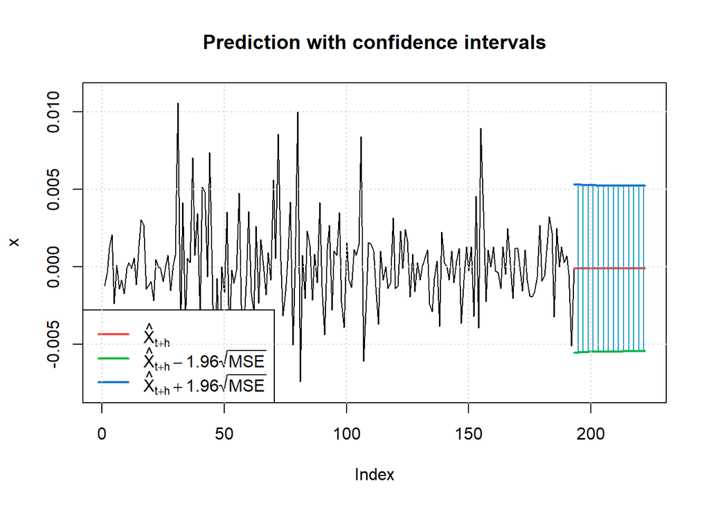

```r
predikciev <- predict(gmodel,n.ahead=30,plot=TRUE)
```

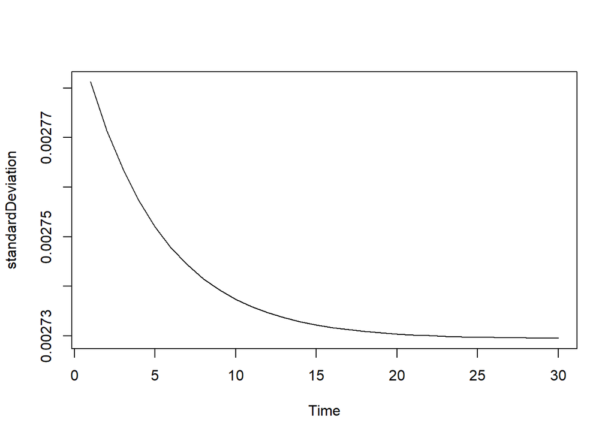

```r
plot(ts(predikciev[3]))
```

## Výpočet Value at Risk

V poslednej časti sa pozrieme na výpočet Value at Risk (VaR) na 5-percentnej hladine. VaR budeme počítať iteračne. Každý deň budeme fitovať GARCH(1,1) proces pre naše dáta a spravíme predikciu volatility na ďalší deň. Odhadovať budeme vždy z posledných 50 pozorovaní.

```r
N <- 50
var.chf <- rep(0, length(vynosy) - N + 1)
for(i in 1:length(var.chf))
{
  data.chf <- vynosy[i:(i+N-1)]
  garch.chf <- garchFit(~garch(1,1), data = data.chf, trace = FALSE)
  pred.chf <- predict(garch.chf, n.ahead = 1, plot = FALSE)
  var.chf[i] <- qnorm(0.05, mean = pred.chf[1,1],sd = pred.chf[1,3])
}
```

Z výnosov a VaR vytvoríme časové rady a vykreslíme do jedného grafu.

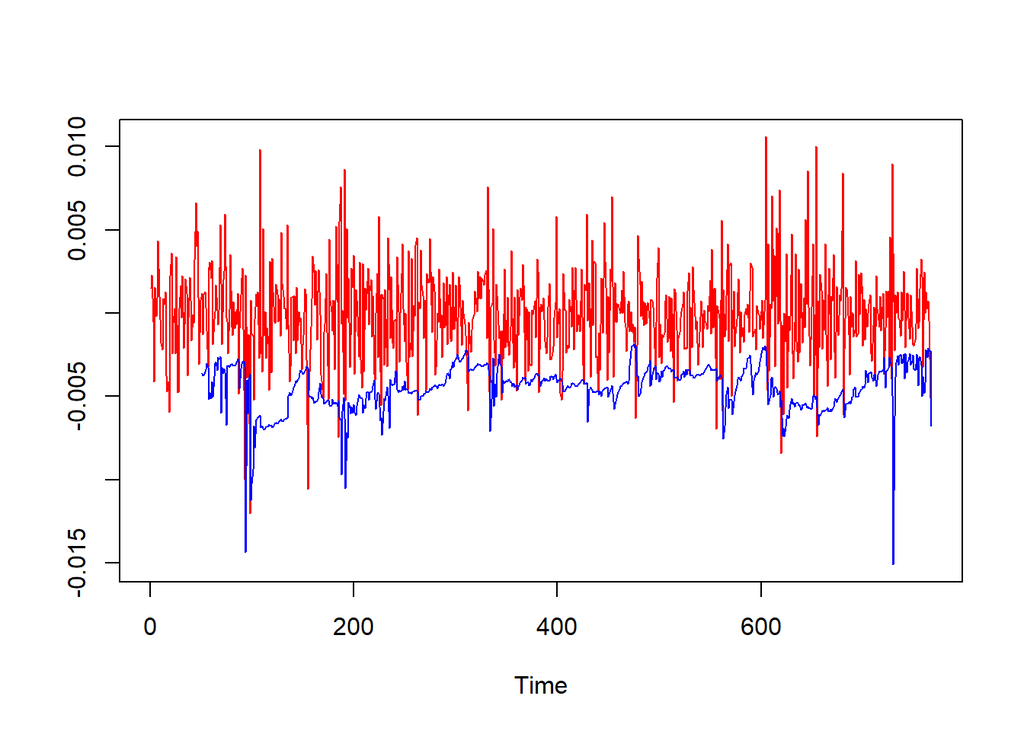

```r
ts.vynosy<-ts(vynosy)
ts.var.chf<-ts(var.chf,start = N+1)
ts.plot(ts.vynosy,ts.var.chf,col=c("red","blue"))
```

Teraz vypočítame frekvenciu prekročení VaR.

```r
pocet <- sum(vynosy[(N + 1):length(vynosy)] < var.chf[-length(var.chf)])
perc <- 100*pocet/length(var.chf[-length(var.chf)])
perc
```

```
## [1] 5.726257
```

Vidíme, že frekvencia prekročení síce prekračuje hladinu 5 percent, avšak nie výrazne. Preto náš model považujeme za pomerne dobrý na výpočet VaR. Overíme si to aj v nasledujúcich testoch.

## Testovanie Value at Risk

Na záver ideme testovať adekvátnosť modelu pri odhadovaní VaR pomocou štatistických testov z cvičení. Ako prvé použijeme Krupiecov test, ktorý testuje, či frekvencia prekročení je zhodná s predefinovanou hladinou VAR.

```r
freq <- pocet/length(var.chf[-length(var.chf)])
celkovy.pocet <- length(var.chf[-length(var.chf)])

LRuc <- 2*log(((1-freq)/(1-0.05))^(celkovy.pocet - pocet)*(freq/0.05)^pocet )

pchisq(LRuc, df = 1, lower.tail = FALSE)
```

```
## [1] 0.3830042
```

P-value testu vyšla výrazne viac ako 5 percent, a preto nulovú hypotézu celkom jednoznačne nezamietame. Teda aj keď pozorovaná frekvencia nám vyšla vyššia ako 5 percent, je to pravdepodobne iba štatistická chyba a frekvencia prekročení je zhodná s predefinovanou hladinou VaR.

Na záver ideme testovať, či sú prekročenia sériovo závislé, keďže aj toto by spôsobovalo problémy. Využijeme na to Christoffersenov test podobne ako na cvičení.

```r
prekrocenia <- (vynosy[(N + 1):length(vynosy)] < var.chf[-length(var.chf)])*1

N00 <- sum( prekrocenia[-1] + prekrocenia[-length(prekrocenia)]==0)
N01 <- sum( prekrocenia[-1] - prekrocenia[-length(prekrocenia)]==1)
N10 <- sum( prekrocenia[-1] - prekrocenia[-length(prekrocenia)]==-1)
N11 <- sum( prekrocenia[-1] + prekrocenia[-length(prekrocenia)]==2)


N0 <- N00 + N10
N1 <- N11 + N01

p01 <- N01/(N01 + N00)
p11 <- N11/(N11 + N10)
p <- (N01 + N11)/(N00 + N01 + N10 + N11)


LRind <- -2*log( ((1-p)^N0 * p^N1) / ((1-p01)^N00 * p01^N01 * (1-p11)^N10 * p11^N11) )
LRind
```

```
## [1] 0.2251367
```

```r
pchisq(LRind, df = 1, lower.tail = FALSE)
```

```
## [1] 0.6351536
```

P-hodnota testu vyšla aj v tomto prípade vysoko nad 5 percent, teda nulovú hypotézu opäť nezamietame. Prekročenia sú sériovo nezávislé.